# Model sensitivity analysis [N+2]

Martin R. Vasilev

May 18, 2016

## Mean N+2 Preview Effect on Word N+2 for All Studies [FFD]

| Prior on $\theta$ | Prior on $\tau$ | Posterior $\theta$ (SD) [95% CrI] | Posterior $\tau$ (SD) [95% CrI] |
| --- | --- | --- | --- |
| **Uniform(-200, 200)** | **Uniform(0, 200)** | 5.39 (3.96) [-2.34, 13.22] | 3.75 (3.19) [0.13, 11.86] |
| Normal(0, $100^2$) | Uniform(0, 200) | 5.34 (3.96) [-2.42, 13.1] | 3.84 (3.24) [0.16, 12.18] |
| Uniform(-200, 200) | Gamma(0.001, 0.001) | 5.06 (3.55) [-1.91, 11.76] | 1.14 (1.74) [0.03, 6.17] |
| Normal(0, $100^2$) | Gamma(0.001, 0.001) | 5.25 (3.63) [-1.78, 12.5] | 1.16 (1.74) [0.03, 6.22] |
| Uniform(-200, 200) | Normal(0, $100^2$) I(0,) | 5.41 (3.92) [-2.23, 13.17] | 3.72 (3.14) [0.1, 11.63] |
| Normal(0, $100^2$) | Normal(0, $100^2$) I(0,) | 5.33 (3.9) [-2.34, 12.94] | 3.84 (3.29) [0.16, 11.97] |

*Note*: For Gamma distributions, the prior is on the precision (i.e. $1/\tau^2$). The priors in bold are the ones on which the results in the paper are based.

## Mean N+2 Preview Effect on Word N+2 Only for Alphabetical Studies [FFD]

| Prior on $\theta$ | Prior on $\tau$ | Posterior $\theta$ (SD) [95% CrI] | Posterior $\tau$ (SD) [95% CrI] |
| --- | --- | --- | --- |
| **Uniform(-200, 200)** | **Uniform(0, 200)** | 3.92 (5.92) [-7.6, 15.41] | 6.15 (5.7) [0.23, 20.76] |
| Normal(0, $100^2$) | Uniform(0, 200) | 3.89 (5.93) [-7.61, 15.68] | 6.21 (5.68) [0.25, 21.01] |
| Uniform(-200, 200) | Gamma(0.001, 0.001) | 4.45 (4.95) [-5.2, 14.34] | 1.67 (2.71) [0.03, 9.56] |
| Normal(0, $100^2$) | Gamma(0.001, 0.001) | 3.85 (4.86) [-5.84, 13.33] | 1.62 (2.79) [0.03, 9.4] |
| Uniform(-200, 200) | Normal(0, $100^2$) I(0,) | 4.03 (5.9) [-7.5, 15.46] | 6.01 (5.62) [0.18, 20.68] |
| Normal(0, $100^2$) | Normal(0, $100^2$) I(0,) | 3.85 (5.92) [-7.85, 15.31] | 6.12 (5.63) [0.21, 20.8] |

*Note*: For Gamma distributions, the prior is on the precision (i.e. $1/\tau^2$). The priors in bold are the ones on which the results in the paper are based.

## Mean N+2 Preview Effect on Word N+2 for All Studies [GD]

| Prior on $\theta$ | Prior on $\tau$ | Posterior $\theta$ (SD) [95% CrI] | Posterior $\tau$ (SD) [95% CrI] |
| --- | --- | --- | --- |
| **Uniform(-200, 200)** | **Uniform(0, 200)** | 5.4 (5.92) [-6.08, 17.12] | 6.42 (5.19) [0.26, 19.3] |
| Normal(0, $100^2$) | Uniform(0, 200) | 5.3 (5.81) [-6.18, 16.86] | 6.4 (5.22) [0.26, 19.49] |
| Uniform(-200, 200) | Gamma(0.001, 0.001) | 5.02 (5.13) [-5.45, 14.65] | 1.83 (2.92) [0.03, 10.51] |
| Normal(0, $100^2$) | Gamma(0.001, 0.001) | 4.91 (5.43) [-5.67, 15.54] | 1.71 (2.79) [0.03, 9.96] |
| Uniform(-200, 200) | Normal(0, $100^2$) I(0,) | 5.4 (5.73) [-5.68, 16.71] | 6.36 (5.27) [0.17, 19.48] |
| Normal(0, $100^2$) | Normal(0, $100^2$) I(0,) | 5.32 (5.81) [-5.92, 16.9] | 6.35 (5.32) [0.21, 19.65] |

*Note*: For Gamma distributions, the prior is on the precision (i.e. $1/\tau^2$). The priors in bold are the ones on which the results in the paper are based.

## Mean N+2 Preview Effect on Word N+2 Only for Alphabetical Studies [GD]

| Prior on $\theta$ | Prior on $\tau$ | Posterior $\theta$ (SD) [95% CrI] | Posterior $\tau$ (SD) [95% CrI] |
| --- | --- | --- | --- |
| **Uniform(-200, 200)** | **Uniform(0, 200)** | 1.77 (8.26) [-14.1, 18.47] | 8.85 (8.02) [0.31, 29.55] |
| Normal(0, $100^2$) | Uniform(0, 200) | 1.72 (8.25) [-13.92, 18.39] | 8.99 (8.21) [0.28, 30.42] |
| Uniform(-200, 200) | Gamma(0.001, 0.001) | 1.45 (6.51) [-10.74, 14.6] | 2.26 (3.81) [0.03, 13.55] |
| Normal(0, $100^2$) | Gamma(0.001, 0.001) | 0.99 (6.74) [-12.12, 14.23] | 2.16 (3.74) [0.03, 13.17] |
| Uniform(-200, 200) | Normal(0, $100^2$) I(0,) | 1.7 (8.14) [-13.99, 18.02] | 8.75 (7.94) [0.32, 29.21] |
| Normal(0, $100^2$) | Normal(0, $100^2$) I(0,) | 1.68 (8.25) [-14.15, 18.32] | 8.92 (8.12) [0.31, 29.61] |

*Note*: For Gamma distributions, the prior is on the precision (i.e. $1/\tau^2$). The priors in bold are the ones on which the results in the paper are based.

## Mean N+2 Preview Effect on Word N+1 [FFD]

| Prior on $\theta$ | Prior on $\tau$ | Posterior $\theta$ (SD) [95% CrI] | Posterior $\tau$ (SD) [95% CrI] |
| --- | --- | --- | --- |
| **Uniform(-200, 200)** | **Uniform(0, 200)** | 6.7 (5.41) [-4, 17.21] | 5.53 (4.82) [0.2, 17.67] |
| Normal(0, $100^2$) | Uniform(0, 200) | 6.74 (5.41) [-3.91, 17.44] | 5.57 (4.89) [0.24, 18.05] |
| Uniform(-200, 200) | Gamma(0.001, 0.001) | 6.5 (4.83) [-2.54, 16.11] | 1.66 (2.63) [0.03, 9.23] |
| Normal(0, $100^2$) | Gamma(0.001, 0.001) | 6.55 (4.89) [-3, 16] | 1.57 (2.5) [0.03, 8.76] |
| Uniform(-200, 200) | Normal(0, $100^2$) I(0,) | 6.71 (5.51) [-4.09, 17.46] | 5.54 (4.91) [0.2, 17.8] |
| Normal(0, $100^2$) | Normal(0, $100^2$) I(0,) | 6.69 (5.47) [-4.08, 17.51] | 5.56 (4.88) [0.21, 17.88] |

*Note*: For Gamma distributions, the prior is on the precision (i.e. $1/\tau^2$). The priors in bold are the ones on which the results in the paper are based.

## Mean N+2 Preview Effect on Word N+1 [GD]

| Prior on $\theta$ | Prior on $\tau$ | Posterior $\theta$ (SD) [95% CrI] | Posterior $\tau$ (SD) [95% CrI] |
| --- | --- | --- | --- |
| **Uniform(-200, 200)** | **Uniform(0, 200)** | 7.44 (6.48) [-5.27, 20.21] | 7.01 (6.01) [0.26, 22.09] |
| Normal(0, $100^2$) | Uniform(0, 200) | 7.46 (6.39) [-4.87, 20.19] | 6.94 (6.09) [0.24, 22.17] |
| Uniform(-200, 200) | Gamma(0.001, 0.001) | 7.64 (5.57) [-3.44, 18.21] | 1.89 (3.11) [0.03, 11.03] |
| Normal(0, $100^2$) | Gamma(0.001, 0.001) | 7.45 (5.62) [-3.72, 18.53] | 1.86 (3.06) [0.03, 10.81] |
| Uniform(-200, 200) | Normal(0, $100^2$) I(0,) | 7.54 (6.5) [-5.27, 20.43] | 6.98 (6.02) [0.28, 22.19] |
| Normal(0, $100^2$) | Normal(0, $100^2$) I(0,) | 7.58 (6.41) [-4.77, 20.1] | 6.96 (6.08) [0.24, 22.56] |

*Note*: For Gamma distributions, the prior is on the precision (i.e. $1/\tau^2$). The priors in bold are the ones on which the results in the paper are based.

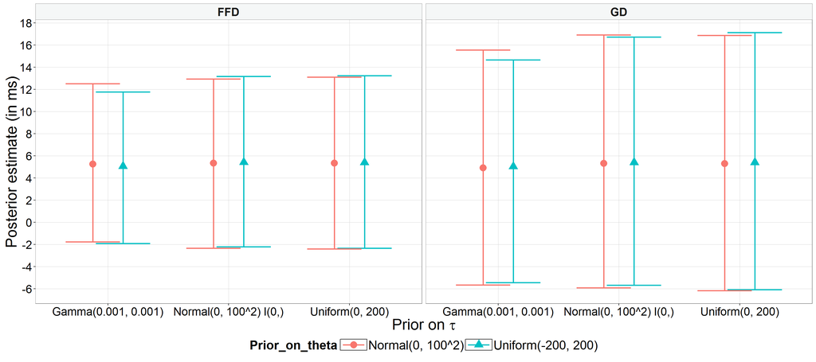